# OurModels

INTRODUCTION

Far away from all models we tried in this project we finally get the 2 best models for our predictions which are gradient boosting method (GBM) and multilinear model (ML). In order to determine which one of those models works better with the data, we trained the models n_times to see if it's good to execute the model more than one time and obtain the values that gives the best r squared for the model. This parameter is called EXHAUSTIVE_ITERATION and it's placed in config.py. We tried different numerical values in exhaustive_iterations for every model and the results are shown next.

```python
import matplotlib.pyplot as plt
```

```python
timeGB=(18.81,250.76,280.13,498.645,575.97)
timeML=(0.45,18.72,22.7,25.41,28.73)
nIterGB=(1,2,3,4,5)
nIterML=(1,10,100,200,300)
rsquaredGB=(0.309,0.305,0.301,0.295,0.304)
rsquaredML=(0.22,0.21,0.24,0.27,0.27)
```

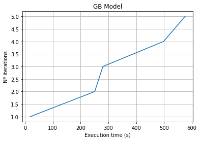

```python
plt.plot(timeGB,nIterGB)
plt.title('GB Model')
plt.xlabel('Execution time (s)')
plt.ylabel('Nº iterations')
plt.grid()
plt.show()
```

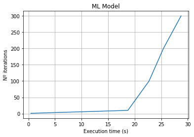

```python
plt.plot(timeML,nIterML)
plt.title('ML Model')
plt.xlabel('Execution time (s)')
plt.ylabel('Nº iterations')
plt.grid()
plt.show()
```

First of all, we can see how fast is the program with different iterations between both models. The first graphic, which is GB model, has execution times so much bigger than ML model. Which means that ML is faster than GB, but the r squared is not as good as GB model, so as what we want is to maximize the r squared value we can say that the GB model works better than ML.

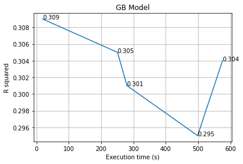

```python
plt.plot(timeGB,rsquaredGB)
plt.title('GB Model')
plt.xlabel('Execution time (s)')
plt.ylabel('R squared')
plt.grid()
for a,b in zip(timeGB, rsquaredGB):
    plt.text(a, b, str(b))
plt.show()
```

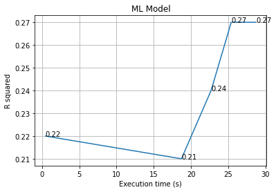

```python
plt.plot(timeML,rsquaredML)
plt.title('ML Model')
plt.xlabel('Execution time (s)')
plt.ylabel('R squared')
plt.grid()
for a,b in zip(timeML, rsquaredML):
    plt.text(a, b, str(b))
plt.show()
```

This two graphics show the execution time and the rsquared obtained when we train the models with different exhaustive_iterations. For GB model we selected the following iterations: 1, 2, 3, 4, 5. And for ML model we selected: 1, 10, 100, 200, 300. The conclusions we obtain with those graphics is to know which is the iterations that maximazes the rsquared. We see that those parameters are the following, 1 and 200, for GB and ML respectively.

Moreover, we can see how bad is working the ML model with low iterations, but when we increase the number of iterations, it achieves a quite good r squared compared with the GB r squareds. So as a conclusion we can extract from this is that ML is a bad model if we don't iterate it so much times in order to get better r squared. Otherwise, GB model works pretty good with no iterations but when we iterate this method we got lower r squared and more time of execution.

Alse to allow variability we changed the random seed in order to not use always the same blocks of informations.

HYPERPARAMETERS OF THE MODELS

gbm_hyperparams = {

```
    'n_estimators': 2000,
    'max_depth': 5,
    'learning_rate': 0.1,
    'loss': 'huber',
    'criterion': 'mse',
    'validation_fraction': 0.01,
    'n_iter_no_change': 20
}
```

That are the parameters we played with to get the best r squared. First of all we're going to explain what is every parameter. The first parameter 'n_estimators' means the number of estimators that we're going to use. 'Max depth' parameter has to be between 1 and 10 because if it's not in that range it's going to give us a negative r squared. 'learning_rate' is the parameter that shows us how our model is going to learn from data. It has a numerical value that in this case has to be 0.1 because if you increases this number the r squared gives negative value too. 'loss' means the loss function we use. There are 5 types of loss and we played with them and we declared that the best one was huber, which is the combination between 2 'loss' types. 'criterion' is what we want to maximize and in our case what we want to maximize is the r squared error so we type mse. There are 2 more types of 'criterion' but that was which gives us a better performance. And finally we have 'n_iter_no_change' and 'validation_fraction' that are parameters that goes together, n_iter_no_change is a parameter that looks what is the error and if the error don't change in the number of iterations that we specify then it stops.